# Homework 3: Forecasting Using Linear Regression

Aral Dörtoğul

1/9/2021

In this homework, the data of the number of newly established firms (total) in Turkey is fitted using linear regression. In order to fit the data in a reasonable linear regression model, different meaningful data series and other components such as trend are selected as factors affecting the number of newly established firms. Then, the next month’s data is forecasted using this fitted linear regression model.

All the R code written for the following plots is [here](https://bu-ie-360.github.io/fall20-araldortogul/files/R-scripts/homework3.R) (.R file).  
The R markdown written for this html document including the code chunks is [here](https://bu-ie-360.github.io/fall20-araldortogul/files/R-scripts/hw3.Rmd) (.Rmd file).  
The data obtained from the CBRT Electronic Delivery System is [here](https://bu-ie-360.github.io/fall20-araldortogul/files/hw3data.csv) (.csv file).

# Introduction

The total number of firms established in a period of time can be influenced by various economic factors. In this exercise, the monthly data of the total number of firms established in Turkey from January 2013 to November 2020 is going to be modeled using interest rates for commercial loans, because people often get commercial loans when they want to establish a new firm, and the interest rates for that loan type is usually checked before getting loans. The other possible economic factors will be analyzed and included later.

# Setting Up Linear Regression Model

The total number of firms established in Turkey with respect to time can be plotted as follows:

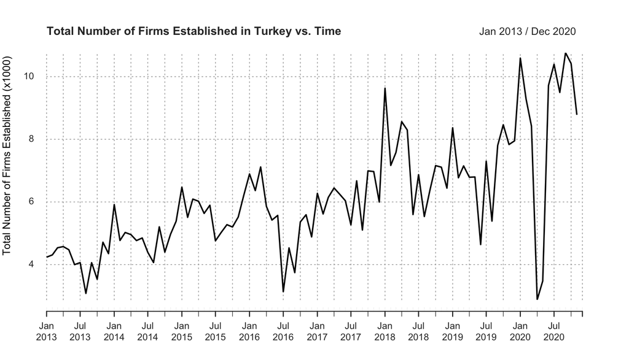

```r
library(ggplot2)    # for plotting
library(forecast)   # forecasting library
library(xts)        # extended time series library

data <- read.csv(file = "hw3data.csv")
data$Date <- as.yearmon(data$Date)
time_series <- xts(x = data[-1], order.by = data$Date, frequency = 12)

plot(time_series$Firms / 1000,
     main = "Total Number of Firms Established in Turkey vs. Time",
     ylab = "Total Number of Firms Established (x1000)",
     xlab = "Time",
     yaxis.right = FALSE,
     minor.ticks = "quarters",
     grid.ticks.on = "quarters",
     grid.ticks.lty = 3)
```

First of all, the data of the number of the established firms show an overall positive trend. The data climbs up starting from approximately four thousand to ten thousand with some white noise. So, a trend component should be included in the model.

In the middle of 2016, there is a sudden drop. In the summer of 2016, there was a Turkish coup d’état attempt (*Turkish: 15 Temmuz darbe girişimi*). This political conflict may have caused people to establish less firms for a couple of months. Because of this, the coup attempt should be included in the model using a logical dummy variable.

In addition to these, a great drop can also be seen in the first half of 2020. The first confirmed COVID-19 case was seen on March 2020 in Turkey and the pandemic quickly spread across the whole country. The quarantine period may have caused this immense drop. Therefore, a variable for COVID-19 puarantine period is also crucial for our model.

Moreover, January data is almost always high, and July data is almost always low. This means that there is some kind of seasonality in our data, and it should be included in our model using a month variable as factor.

Last but not least, the deviation tends to be increasing as years pass. This can be a problem while modeling and the data should be modified in a way that the change in deviation is minimized. In order to do that, the natural logarithm of the data can be used instead.

```r
data$Firms <- log(data$Firms)
data$month <- rep(1:12, 8)

data$coup <- rep(0,96)
data$coup[43:45] <- rep(1,3)

data$covid <- rep(0,96)
data$covid[88:89] <- c(1,1)

data$trend <- 1:96

time_series <- xts(x = data[-1], order.by = data$Date, frequency = 12)
model <- lm(formula = Firms ~ trend + CommercialLoan + as.factor(month) + coup + covid, data = time_series)
summary(model)
```

```
##
## Call:
## lm(formula = Firms ~ trend + CommercialLoan + as.factor(month) +
##     coup + covid, data = time_series)
##
## Residuals:
##      Min       1Q   Median       3Q      Max
## -0.34238 -0.07332  0.01119  0.08566  0.23225
##
## Coefficients:
##                      Estimate Std. Error t value Pr(>|t|)
## (Intercept)         8.6254697  0.0566418 152.281  < 2e-16 ***
## trend               0.0094115  0.0005395  17.445  < 2e-16 ***
## CommercialLoan     -0.0111500  0.0027952  -3.989 0.000147 ***
## as.factor(month)2  -0.1581939  0.0602360  -2.626 0.010365 *
## as.factor(month)3  -0.1134044  0.0602407  -1.883 0.063447 .
## as.factor(month)4  -0.1266382  0.0613844  -2.063 0.042394 *
## as.factor(month)5  -0.1469775  0.0613503  -2.396 0.018954 *
## as.factor(month)6  -0.2677686  0.0602794  -4.442 2.87e-05 ***
## as.factor(month)7  -0.2665505  0.0610306  -4.367 3.78e-05 ***
## as.factor(month)8  -0.3113213  0.0610593  -5.099 2.29e-06 ***
## as.factor(month)9  -0.2152712  0.0611690  -3.519 0.000721 ***
## as.factor(month)10 -0.2103863  0.0604080  -3.483 0.000812 ***
## as.factor(month)11 -0.1943279  0.0604145  -3.217 0.001881 **
## as.factor(month)12 -0.2335409  0.0623942  -3.743 0.000343 ***
## coup               -0.3777993  0.0744964  -5.071 2.55e-06 ***
## covid              -1.1458892  0.0981179 -11.679  < 2e-16 ***
## ---
## Signif. codes:  0 '***' 0.001 '**' 0.01 '*' 0.05 '.' 0.1 ' ' 1
##
## Residual standard error: 0.1205 on 79 degrees of freedom
##   (1 observation deleted due to missingness)
## Multiple R-squared:  0.853,  Adjusted R-squared:  0.825
## F-statistic: 30.55 on 15 and 79 DF,  p-value: < 2.2e-16
```

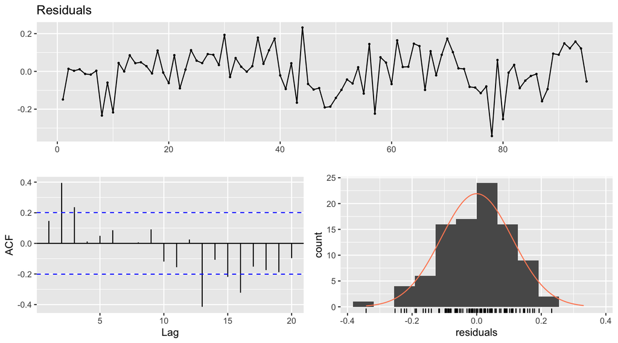

```
##
##  Breusch-Godfrey test for serial correlation of order up to 19
##
## data:  Residuals
## LM test = 43.022, df = 19, p-value = 0.001287
```

```r
checkresiduals(model)
```

According to our current model, the trend component, seasonality and interest rates for commercial loans are significant factors. Also, the dummy variables for the coup attempt and the quarantine period for COVID-19 are also satisfying variables for our model. Although adjusted R-squared (0.82) is not that low and the mean of residuals are almost 0, the problem with this model is that residuals are distributed in an autocorrelated fashion. They need to be distributed independently. This initial model needs to be improved by adding or subtracting variables.

# Adding New Variables

## Industrial Production Index

In Central Bank of the Republic of Turkey’s (CBRT) database, industrial production index can be obtained under the tab “Production Statistics”. IPI is basically an economic indicator that measures the real production output of manufacturing, mining, and utilities such as technology. This might be beneficial for our model.

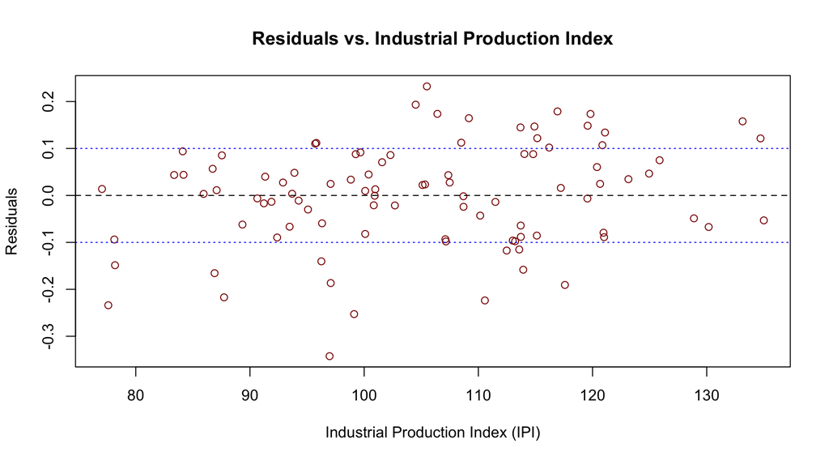

```r
plot(x = data$IPI[1:95], y = model$residuals[1:95], col = "darkred",
     main = "Residuals vs. Industrial Production Index",
     xlab = "Industrial Production Index (IPI)",
     ylab = "Residuals")
abline(h = 0, lty = 2)
abline(h = 0.1, lty = 3, col = "blue")
abline(h = -0.1, lty = 3, col = "blue")
```

When the scatter plot of residuals and IPI is drawn, it appears that the residuals are distributed around the mean zero and the points are not scattered all around the plot. Because of this correlation, IPI will be included in the model.

## USD/TRY Exchange Rates

Exchange rates are an important economic factor affecting several other economic factors in daily life. If we plot residuals vs. USD/TRY exchange rates:

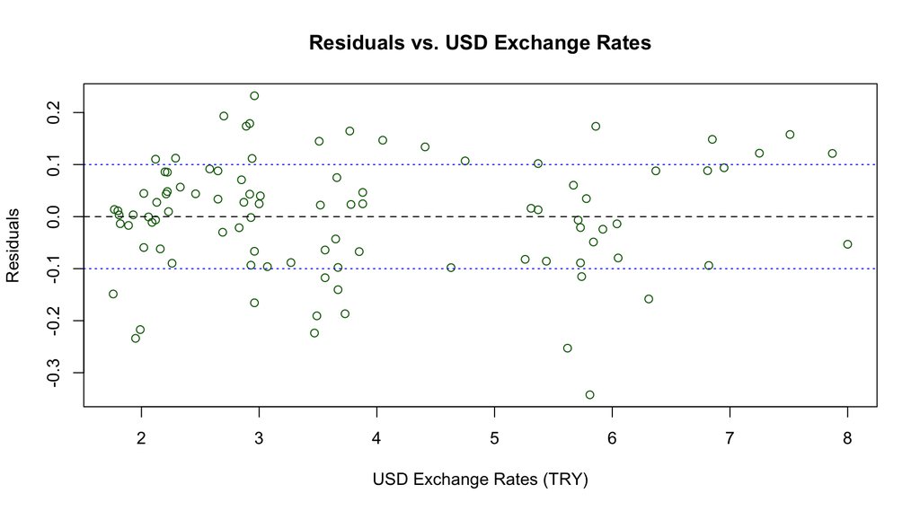

```r
plot(x = data$USD[1:95], y = model$residuals[1:95], col = "darkgreen",
     main = "Residuals vs. USD Exchange Rates",
     xlab = "USD Exchange Rates (TRY)",
     ylab = "Residuals")
abline(h = 0, lty = 2)
abline(h = 0.1, lty = 3, col = "blue")
abline(h = -0.1, lty = 3, col = "blue")
```

The scatter plot reveals that although the residuals are near 0 for low exchange rate values, the same thing cannot be observed for high exchange rate values. Hence, USD exchange rates won’t be included in the model.

# Updated Linear Regression Model

Our model now includes IPI in addition to the previous variables:

```r
model <- lm(formula = Firms ~ trend + CommercialLoan + IPI + as.factor(month) + coup + covid, data = time_series)
summary(model)
```

```
##
## Call:
## lm(formula = Firms ~ trend + CommercialLoan + IPI + as.factor(month) +
##     coup + covid, data = time_series)
##
## Residuals:
##      Min       1Q   Median       3Q      Max
## -0.20727 -0.07102  0.02143  0.06031  0.19782
##
## Coefficients:
##                      Estimate Std. Error t value Pr(>|t|)
## (Intercept)         7.6252959  0.1639217  46.518  < 2e-16 ***
## trend               0.0045628  0.0008805   5.182 1.68e-06 ***
## CommercialLoan     -0.0087591  0.0023135  -3.786 0.000299 ***
## IPI                 0.0123403  0.0019403   6.360 1.26e-08 ***
## as.factor(month)2  -0.1438232  0.0492448  -2.921 0.004567 **
## as.factor(month)3  -0.2415618  0.0531636  -4.544 1.99e-05 ***
## as.factor(month)4  -0.2398075  0.0531951  -4.508 2.27e-05 ***
## as.factor(month)5  -0.3063278  0.0560184  -5.468 5.29e-07 ***
## as.factor(month)6  -0.3411773  0.0505634  -6.748 2.37e-09 ***
## as.factor(month)7  -0.3746502  0.0526602  -7.114 4.77e-10 ***
## as.factor(month)8  -0.3583684  0.0504109  -7.109 4.88e-10 ***
## as.factor(month)9  -0.3592775  0.0548467  -6.551 5.57e-09 ***
## as.factor(month)10 -0.3950766  0.0572456  -6.901 1.21e-09 ***
## as.factor(month)11 -0.3936309  0.0584491  -6.735 2.51e-09 ***
## as.factor(month)12 -0.4850510  0.0645004  -7.520 7.95e-11 ***
## coup               -0.2757503  0.0629193  -4.383 3.62e-05 ***
## covid              -0.6062015  0.1167107  -5.194 1.60e-06 ***
## ---
## Signif. codes:  0 '***' 0.001 '**' 0.01 '*' 0.05 '.' 0.1 ' ' 1
##
## Residual standard error: 0.09838 on 78 degrees of freedom
##   (1 observation deleted due to missingness)
## Multiple R-squared:  0.9032, Adjusted R-squared:  0.8833
## F-statistic: 45.47 on 16 and 78 DF,  p-value: < 2.2e-16
```

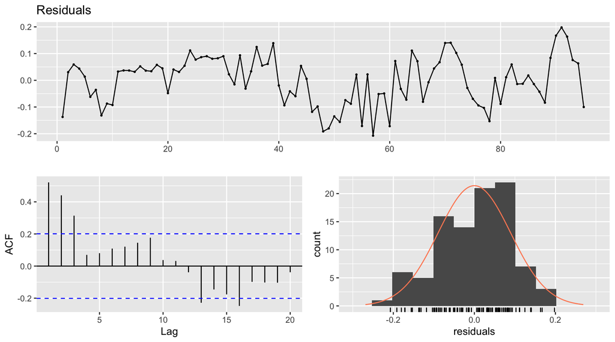

```
##
##  Breusch-Godfrey test for serial correlation of order up to 20
##
## data:  Residuals
## LM test = 44.719, df = 20, p-value = 0.001205
```

```r
checkresiduals(model)
```

After the inclusion of industrial production index (IPI), the model’s adjusted R-squared value increased from 0.82 to 0.88, which means that IPI is a strong factor when forecasting the number of firms established. However, the model is not perfect yet. There is still great evidence against the hypothesis that the residuals are not autocorrelated. This needs to be fixed.

# Final Linear Regression Model

In order to fix the residual autocorrelation, the lagged values of the residuals can be included in the model. If we add the lag 1 of the residuals:

```r
data$residual_lag1 <- c(0, model$residuals)

time_series <- xts(x = data[-1], order.by = data$Date, frequency = 12)

model <- lm(formula = Firms ~ trend + CommercialLoan + IPI + residual_lag1 + as.factor(month) + coup + covid, data = time_series)
summary(model)
```

```
##
## Call:
## lm(formula = Firms ~ trend + CommercialLoan + IPI + residual_lag1 +
##     as.factor(month) + coup + covid, data = time_series)
##
## Residuals:
##      Min       1Q   Median       3Q      Max
## -0.21470 -0.04613  0.01053  0.04864  0.15485
##
## Coefficients:
##                      Estimate Std. Error t value Pr(>|t|)
## (Intercept)         7.4448567  0.1419604  52.443  < 2e-16 ***
## trend               0.0035661  0.0007637   4.670 1.25e-05 ***
## CommercialLoan     -0.0080219  0.0019573  -4.098 0.000102 ***
## IPI                 0.0145722  0.0016842   8.652 5.61e-13 ***
## residual_lag1       0.5688281  0.0998571   5.696 2.13e-07 ***
## as.factor(month)2  -0.1410978  0.0415748  -3.394 0.001092 **
## as.factor(month)3  -0.2645443  0.0450612  -5.871 1.04e-07 ***
## as.factor(month)4  -0.2660015  0.0451416  -5.893 9.46e-08 ***
## as.factor(month)5  -0.3407195  0.0476741  -7.147 4.38e-10 ***
## as.factor(month)6  -0.3540358  0.0427448  -8.283 2.90e-12 ***
## as.factor(month)7  -0.3948691  0.0445968  -8.854 2.29e-13 ***
## as.factor(month)8  -0.3674989  0.0425867  -8.629 6.22e-13 ***
## as.factor(month)9  -0.3861392  0.0465407  -8.297 2.72e-12 ***
## as.factor(month)10 -0.4278670  0.0486679  -8.792 3.03e-13 ***
## as.factor(month)11 -0.4287708  0.0497264  -8.623 6.41e-13 ***
## as.factor(month)12 -0.5382837  0.0552468  -9.743 4.47e-15 ***
## coup               -0.2473846  0.0533488  -4.637 1.42e-05 ***
## covid              -0.4600090  0.1018138  -4.518 2.22e-05 ***
## ---
## Signif. codes:  0 '***' 0.001 '**' 0.01 '*' 0.05 '.' 0.1 ' ' 1
##
## Residual standard error: 0.08305 on 77 degrees of freedom
##   (1 observation deleted due to missingness)
## Multiple R-squared:  0.9319, Adjusted R-squared:  0.9168
## F-statistic: 61.96 on 17 and 77 DF,  p-value: < 2.2e-16
```

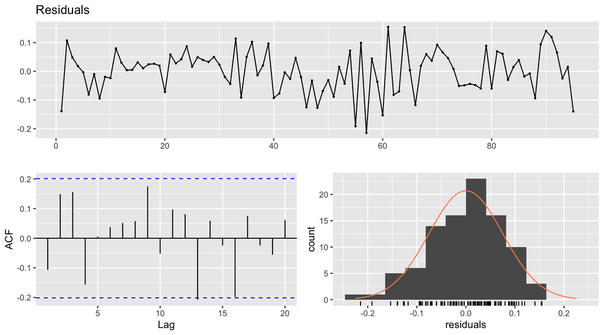

```
##
##  Breusch-Godfrey test for serial correlation of order up to 21
##
## data:  Residuals
## LM test = 22.577, df = 21, p-value = 0.3669
```

```r
checkresiduals(model)
```

With the addition of the lagged values of the residuals, the autocorrelation problem is fixed. This model has an adjusted R-squared value of 0.9168, which means that it is a trustworthy model for predicting the number of firms established in Turkey in a month. Also, the p-value obtained with the *Breusch-Godfrey* test for serial correlation is not small enough to reject the null hypothesis that there is no serial correlation.

# Conclusion

If we plot the real and predicted values of the number of firms established:

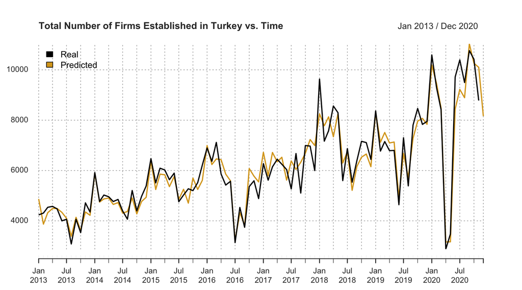

```r
final <- xts(x = data.frame(exp(data$Firms[1:96]),exp(predict(model, time_series))), order.by = data$Date[1:96], frequency = 12)
colnames(final) <- c("Real", "Predicted")
plot(final,
     legend.loc = "topleft",
     main = "Total Number of Firms Established in Turkey vs. Time",
     minor.ticks = "quarters",
     grid.ticks.on = "quarters",
     yaxis.right = FALSE, col = c("black","goldenrod"),
     grid.ticks.lty = 3)
```

The predicted values and the real numbers are so close to each other. The December 2020 is predicted as:

```r
final$Predicted[96]
```

```
##          Predicted
## Dec 2020  8160.673
```

It is very probable that the real december value is going to be very close to **8160.673**.

There are probably countless factors determining the number of firms established in a period of time. Still, with only the current variables, a decent model can be constructed. The final model can explain the ups and downs of the data in a significant level.